# R Boot Camp

Let’s change some of these elements for our geom_point chart using class and cyl

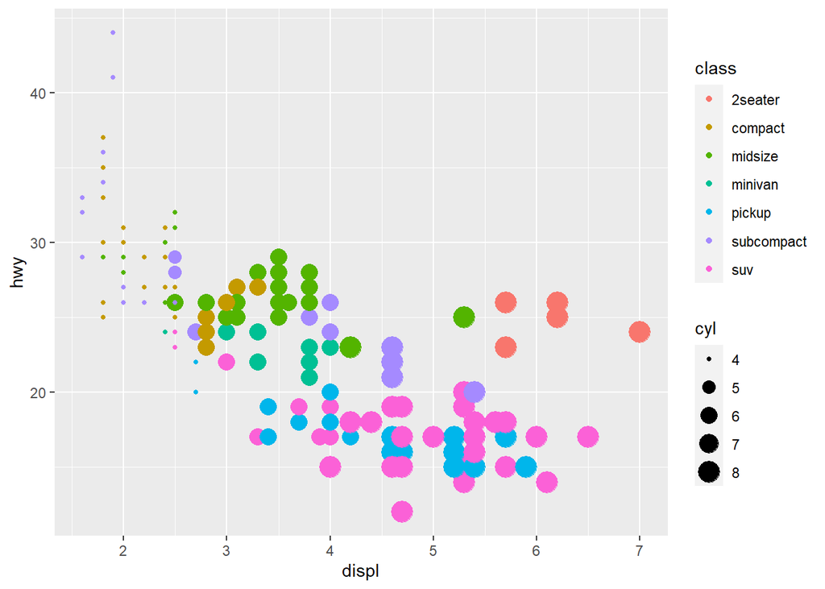

```r
ggplot(data = mpg) +
  geom_point(aes(x = displ, y = hwy, color = class, size = cyl))
```

You can also “hard code” these display elements by leaving them outside of the aes() assignment

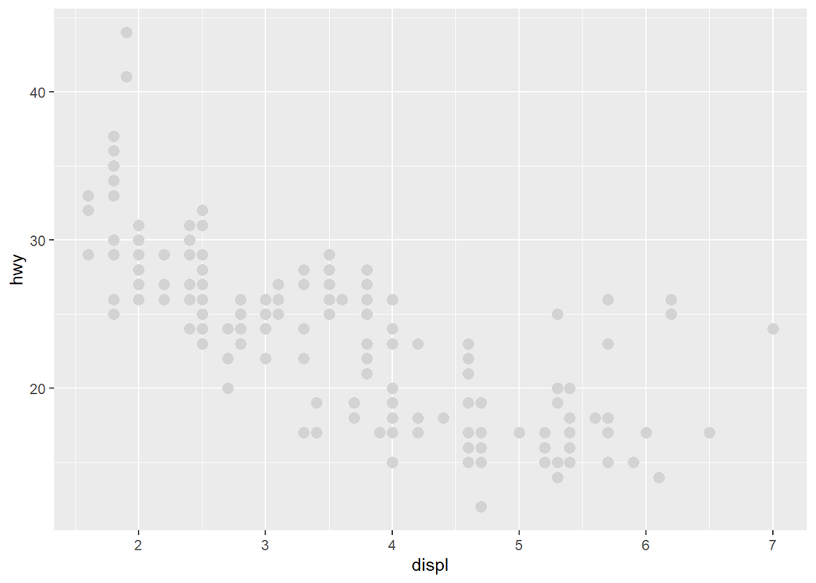

```r
ggplot(data = mpg) +
  geom_point(aes(x = displ, y = hwy), color = "light grey", size = 3)
```

Regarding colors. Most common colors are there along with “dark” and “light” prefixes but for truely custom color you can use a custom color like “#FF33FF”

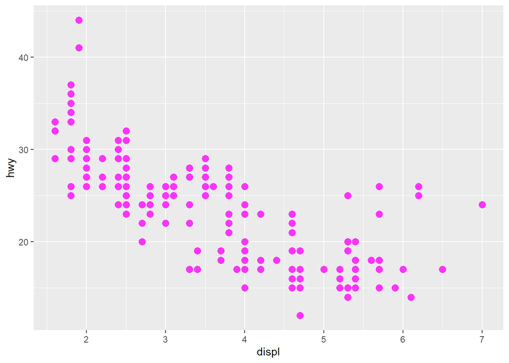

```r
ggplot(data = mpg) +
  geom_point(aes(x = displ, y = hwy), color = "#FF33FF", size = 3)
```

These custom colors are RGB Hexadecimal. First two positions are Red, 2nd two are Green, 3rd two are Blue. Values are on the hexadecimal scale from 0 to F (16 possible values per position). FFFFFF is pure white 000000 is pure black

Good Visual Resources For Choosing Colors https://color.adobe.com/create/color-wheel https://htmlcolorcodes.com/color-picker/